[figure not shown]

# Exploratory Data Analysis Project (Writeup)

## for summer internship in Shree Cement

**Name** - *Anshul Barjatya*

**Roll NO.** - *18145015*

**Branch** - *Metallurgical Engineering*

[figure not shown]

## What is Exploratory Data Analysis

> *Exploratory Data Analysis*, or *EDA*, is essentially a type of storytelling for statisticians. It is nothing but a data exploration technique to understand the various aspects of the Data.

## What is The Objective of EDA

> It is basically used to filter the data from redundancies.

**The objectives of EDA are to:**

- Suggest hypotheses about the causes of observed phenomena
- Assess assumptions on which statistical inference will be based
- Support the selection of appropriate statistical tools and techniques
- Provide a basis for further data collection through surveys or experiments

## What are The Steps involved in EDA

> It follows a systematic set of steps to explore the data in most efficient way possible.

### Basic Steps in Data Exploration and Preprocessing:

- Identification of variables and data types
- Analyzing the basic metrics
- Non-Graphical Univariate Analysis
- Graphical Univariate Analysis
- Bivariate Analysis
- Variable transformations
- Missing value treatment
- Outlier treatment
- Correlation Analysis
- Dimensionality Reduction

**Here We discuss :**

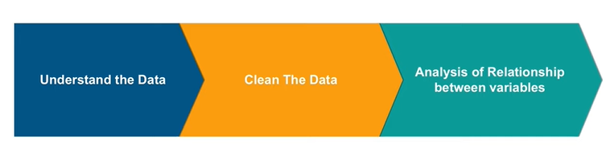

*So Now I am bringing a dataset from Kaggle and performing EDA on it*

> [Source](https://www.kaggle.com/spscientist/students-performance-in-exams?select=StudentsPerformance.csv)

[figure not shown]

```python
import numpy as np
import pandas as pd
import seaborn as sns
```

```python
data=pd.read_csv("C:/Users/ANSHUL JAIN/Desktop/Python Data Analysis/StudentsPerformance.csv")
```

**Step#1. understanding the data**

```python
# for getting the head part of Dataset for our reference.
data.head()
```

|  | gender | race/ethnicity | parental level of education | lunch | test preparation course | math score | reading score | writing score |
| --- | --- | --- | --- | --- | --- | --- | --- | --- |
| 0 | female | group B | bachelor's degree | standard | none | 72 | 72 | 74 |
| 1 | female | group C | some college | standard | completed | 69 | 90 | 88 |
| 2 | female | group B | master's degree | standard | none | 90 | 95 | 93 |
| 3 | male | group A | associate's degree | free/reduced | none | 47 | 57 | 44 |
| 4 | male | group C | some college | standard | none | 76 | 78 | 75 |

```python
# for describing the stats
data.describe()
```

|  | math score | reading score | writing score |
| --- | --- | --- | --- |
| count | 1000.00000 | 1000.000000 | 1000.000000 |
| mean | 66.08900 | 69.169000 | 68.054000 |
| std | 15.16308 | 14.600192 | 15.195657 |
| min | 0.00000 | 17.000000 | 10.000000 |
| 25% | 57.00000 | 59.000000 | 57.750000 |
| 50% | 66.00000 | 70.000000 | 69.000000 |
| 75% | 77.00000 | 79.000000 | 79.000000 |
| max | 100.00000 | 100.000000 | 100.000000 |

```python
# no. of rows and columns
data.shape
```

```
(1000, 8)
```

```python
# To get the names of different columns in dataset
data.columns
```

```
Index(['gender', 'race/ethnicity', 'parental level of education', 'lunch',
       'test preparation course', 'math score', 'reading score',
       'writing score'],
      dtype='object')
```

```python
# To know how many unique data posses by particular column
data.nunique()
```

```
gender                          2
race/ethnicity                  5
parental level of education     6
lunch                           2
test preparation course         2
math score                     81
reading score                  72
writing score                  77
dtype: int64
```

```python
data["gender"].unique()
```

```
array(['female', 'male'], dtype=object)
```

```python
data["race/ethnicity"].unique()
```

```
array(['group B', 'group C', 'group A', 'group D', 'group E'],
      dtype=object)
```

```python
data["parental level of education"].unique()
```

```
array(["bachelor's degree", 'some college', "master's degree",
       "associate's degree", 'high school', 'some high school'],
      dtype=object)
```

**Step#2. Cleaning the data**

```python
# checking that is there any null value in dataset
data.isnull().sum()
```

```
gender                         0
race/ethnicity                 0
parental level of education    0
lunch                          0
test preparation course        0
math score                     0
reading score                  0
writing score                  0
dtype: int64
```

```python
# Now we would remove the unnecessary columns in our dataset which is called dropping the redundant data
# which does not influence our dataset
student= data.drop(['race/ethnicity', 'parental level of education'], axis=1)
```

```python
student.head()
```

|  | gender | lunch | test preparation course | math score | reading score | writing score |
| --- | --- | --- | --- | --- | --- | --- |
| 0 | female | standard | none | 72 | 72 | 74 |
| 1 | female | standard | completed | 69 | 90 | 88 |
| 2 | female | standard | none | 90 | 95 | 93 |
| 3 | male | free/reduced | none | 47 | 57 | 44 |
| 4 | male | standard | none | 76 | 78 | 75 |

**Step#3. Relationship Analysis**

```python
# correlation matrix
# Correlation is a statistic that measures the degree to which two variables move in relation to each other.
corelation=student.corr()
```

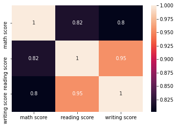

```python
sns.heatmap(corelation, xticklabels=corelation.columns, yticklabels=corelation.columns, annot=True )
```

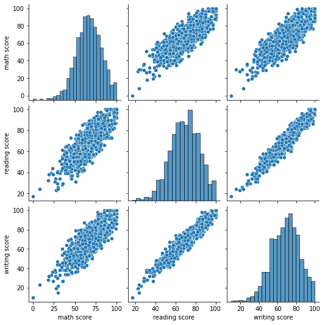

```python
sns.pairplot(student)
```

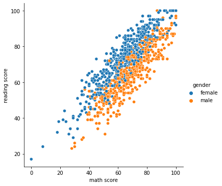

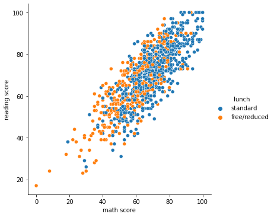

```python
# Scatter Plots
# A scatter plot is a type of plot or mathematical diagram using Cartesian coordinates
# to display values for typically two variables for a set of data.
# Scatter plots are important in statistics because they can show the extent of correlation,
# if any, between the values of observed quantities or phenomena (called variables).
sns.relplot(x='math score', y='reading score', hue='gender', data=student)
sns.relplot(x='math score', y='reading score', hue='lunch', data=student)
```

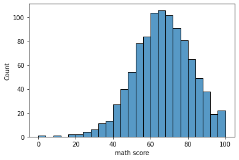

```python
# Histogram
# A histogram is an approximate representation of the distribution of numerical data.
sns.histplot(student['math score'])
```

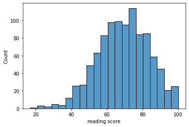

```python
sns.histplot(student['reading score'])
```

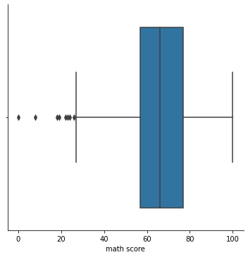

```python
# catigorical plots
sns.catplot(x='math score', kind='box', data=student)
```

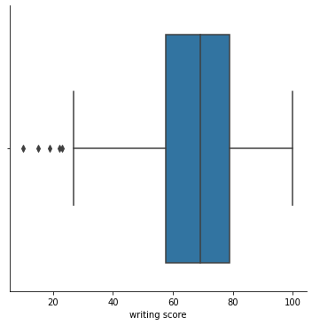

```python
sns.catplot(x='writing score', kind='box', data=student)
```

[figure not shown]

[figure not shown]